# Module 7, End of Course Project

## The Baltimore Orioles and Manny Machados Performance

One of my course objectives was to connect with my son, Anthony, on Sports. To help achieve this, I decided for my project to use the baseball metrics I learned about during the course to analyze my son’s favorite baseball team, the Baltimore Orioles, and his favorite baseball player, Manny Machado.

Anthony was a Baltimore Orioles fan from about 2011 until 2018 when Manny Machado left the team. We took a mother/son trip to Baltimore in 2013. Anthony was 10. We attended the June 26, 2013 game against the Cleveland Indians where they won 7-3 and the June 27, 2013 game against the New York Yankees where they won 4-3. With 40,000 fans in attendance at Camden Yards, it is a memory we will never forget.

Each night, we arrived to the game two hours early and after the game, we would hurry to the player parking exit trying to see of one of the players might stop for an autograph on the way out. You know you have a BIG FAN when at 10 years old your son wants to spend 7 hours at the field for any chance of seeing his favorite player.

I never really understood why the Orioles became his favorite team. I assumed they must be a winning team. We are not from Maryland and Manny wasn’t playing for the team when he became a fan in 2011 (at age 8). Manny did join the team in 2012 and even though the Orioles had some tough years, Manny seemed to be the reason Anthony continued to root for them.

For the team review: I will look at the Baltimore Orioles Win Percent (Wpct) and how that compared to the Pythagorean Expectation predicted win percentage (ExpWpct) from 2009 to 2019.

For the player review: I will look at the value Manny Machado added to the Orioles while playing for them from 2012 to 2018 by comparing Manny’s value (Runs Created and WAR) to the value other known 3rd basemen had. I will focus on player statics from their 1st, 3rd, 5th and 8th seasons.

### Baltimore Oriole’s Team Review - Win Percent (Wpct) and how that Compared to Pythagorean Expectation Predicted Win Percentage (ExpWpct)

Then I will create the ExpWpct variable that calculates the Pythagorean Expectation predicted win percentage. The Pythagorean Expectations formula is runs to the second power divided by runs to the second power plus runs allowed to the second power (R2/(R2+RA2)) and is essentially the *percentage of games a team “should” or is “expected” to win*.

```r
teams = teams %>% mutate(Wpct = W/(W+L)) %>% mutate(ExpWpct = (R^2)/(R^2 + RA^2))
```

| yearID | teamID | Wpct | ExpWpct |
| --- | --- | --- | --- |
| 2009 | BAL | 0.395061728395062 | 0.417089961920519 |
| 2010 | BAL | 0.407407407407407 | 0.378801686300522 |
| 2011 | BAL | 0.425925925925926 | 0.403963689816128 |
| 2012 | BAL | 0.574074074074074 | 0.504939893562451 |
| 2013 | BAL | 0.524691358024691 | 0.524744116039807 |
| 2014 | BAL | 0.592592592592593 | 0.585648906411649 |
| 2015 | BAL | 0.5 | 0.514221873362613 |
| 2016 | BAL | 0.549382716049383 | 0.51986877806381 |
| 2017 | BAL | 0.462962962962963 | 0.438367227017541 |
| 2018 | BAL | 0.290123456790123 | 0.327161349898693 |

[output cut: 1 more lines]

In reviewing the plot of Wpct versus ExpWpct the “expected win percent” appears to be a strong predictor of actual “win percent”. There is a moderate to strong positive relationship although you can see from table that ExpWpct was less than Wpct for 6 out of 10 years and the biggest gap between ExpWpct and Wpct was in 2012 when they were expected to win about 50% of games and they ended up winning about 57%.

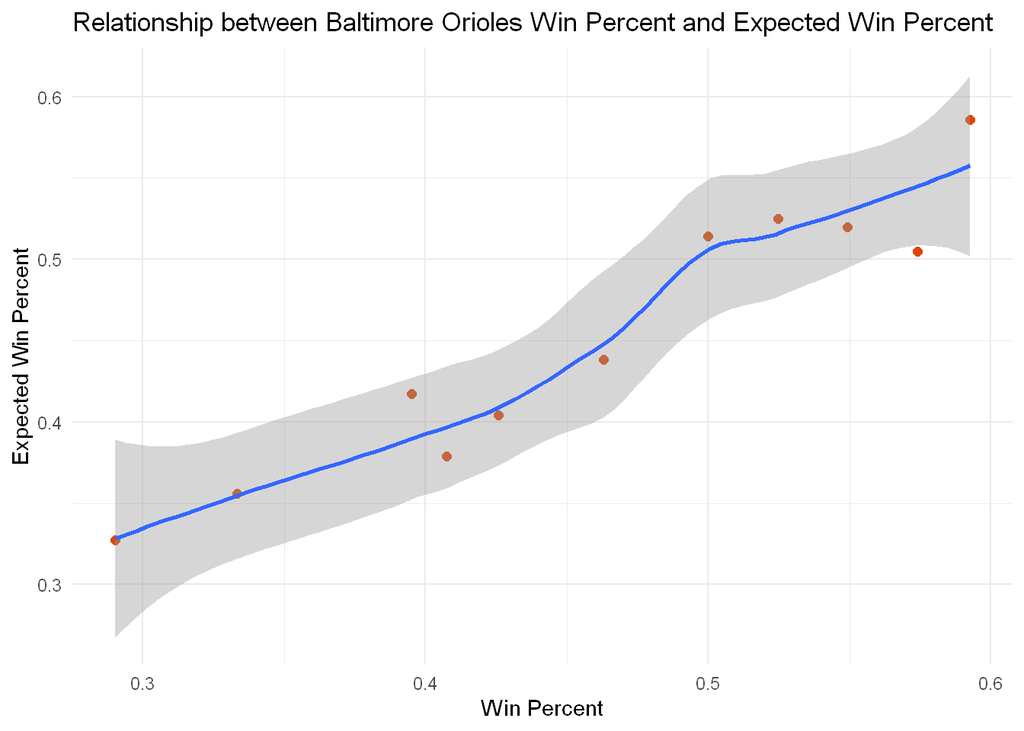

The Orioles best season from 2009 to 2019 was 2014. They had almost a 59% win percent that year. There win percent lept from 43% in 2011 to 57% in 2012, the year Manny Machado joined the team. It remained between 50% and 59% over the next five years (2012 to 2016). They had some great years, outperforming projections year over year, but in 2018 they took a significant drop in wins.

Could this have had anything to with them trading Manny Machado to the Dodgers in 2018 (ended up with the San Diego Padres)? The Orioles entered the 2018 season with signs of being playoff contenders, but after trading Zach Britton to the Yankees, Jonathan Schoop to the Brewers, Brad Brach, Darren O’Day and Kevin Gausman to the Braves; Manny’s leaving seemed to be the last straw and they ended 2018 with only a 29% Wpct.

Will they turn things around? 2019 seemed to be a little better than 2018.

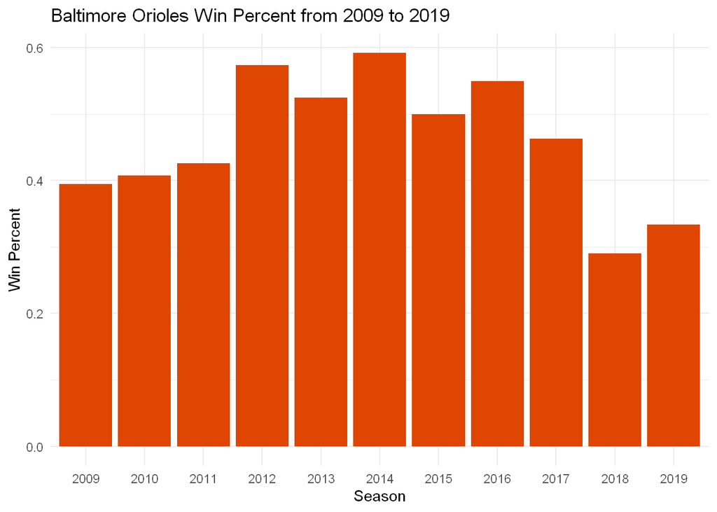

### Manny Machado Peer Comparison - A Comparison of Runs Created and WAR to other Known 3rd Base Players.

So did Manny really make Anthony a fan?

If I compare Manny’s performance to other 3rd Base Players, does he really stand out? I decided to check it out. The players I included are:

- Ryan Zimmerman ~ Washington Nationals
- Rafael Devers ~ Boston Red Sox
- Nolan Arenado ~ Colorado Rockies
- Nicholas Castellanos ~ Detroit Tigers
- Manny Machado ~ Baltimore Orioles
- Kyle Seager ~ Seattle Mariners
- Kris Bryant ~ Chicago Cubs
- Anthony Rendon ~ Washington Nationals

I pulled the stats for each of these players from their 1st, 3rd, 5th and 8th Seasons playing.

Note: Rafael Devers and Kris Bryant haven’t played an 8th Season yet. The low average run figure for Season 8 is because Season 8 was in 2020 for three of the players (Nolan Arenado, Nicholas Castellanos and Anthony Rendon) and the 2020 Season was cut short due to COVID.

```r
mean(Players$R)
```

```
## [1] 62.44828
```

```r
aggregate(x = Players$R, by = list(Players$Season), FUN = mean)
```

```
##   Group.1        x
## 1       1 32.87500
## 2       3 79.75000
## 3       5 94.57143
## 4       8 41.33333
```

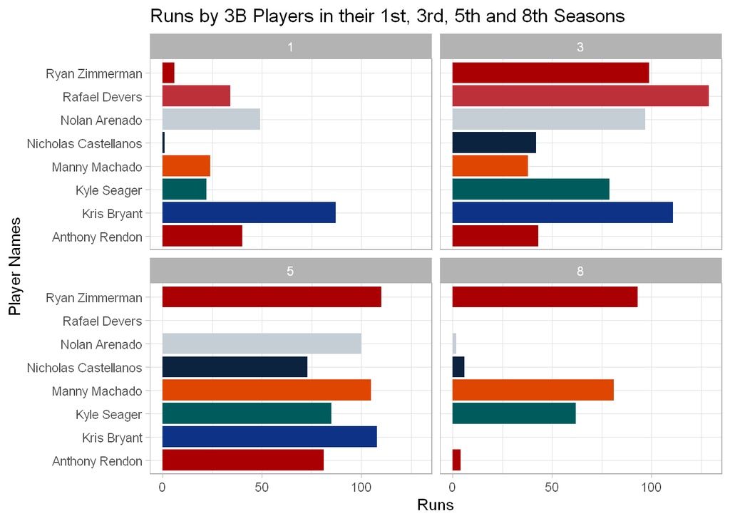

Next I will look at *Runs Created*. Runs created (RC) is calculated as hits plus walks times total bases divided by at bats plus walks ((H+BB)*TB)/(AB+BB)).

Runs created is an indicator of how many runs have resulted from a player. Not only the runs they made, but the runs they created from hitting singles, doubles, triples, home runs, etc.

```r
Players = Players %>% mutate(RC = ((H+BB)*TB)/(AB+BB))
```

| Name | Season | R | RC | WAR |
| --- | --- | --- | --- | --- |
| Nolan Arenado | 1 | 49 | 59.2161100196464 | 2.5 |
| Anthony Rendon | 1 | 40 | 45.1204188481675 | 0.4 |
| Kris Bryant | 1 | 87 | 99.1556603773585 | 5.3 |
| Ryan Zimmerman | 1 | 6 | 14.0655737704918 | 0.6 |
| Rafael Devers | 1 | 34 | 36.1125 | 0.9 |
| Nicholas Castellanos | 1 | 1 | 1.38888888888889 | -0.2 |
| Manny Machado | 1 | 24 | 25.075 | 1.6 |
| Kyle Seager | 1 | 22 | 21.2307692307692 | 0.9 |
| Nolan Arenado | 3 | 97 | 114.913846153846 | 6.3 |
| Anthony Rendon | 3 | 43 | 38.4265129682997 | 0.5 |

[output cut: 19 more lines]

```r
mean(playerstable$RC)
```

```
## [1] 69.96139
```

```r
aggregate(x = playerstable$RC, by = list(playerstable$Season), FUN = mean)
```

```
##   Group.1         x
## 1       1  37.67062
## 2       3  87.58475
## 3       5 109.44429
## 4       8  43.45458
```

In reviewing the plot of Runs versus Runs Created there is a strong positive relationship.

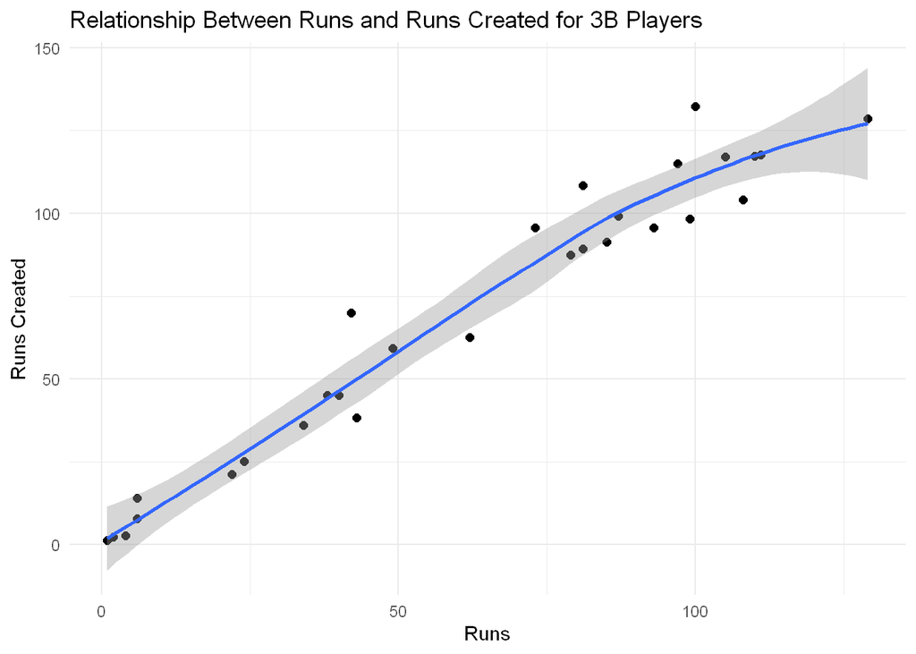

Next I will create a simple linear regression model using runs created to predict runs. Runs = slope times Runs Created plus intercept (R = (0.893)(RC)+(-0.061)). With a p value of <2e-16 *** being less than 0.05, we can say that RC is a significant predictor of R.

Recall that R-squared ranges from 0 to 1. A value of 1 would indicate a “perfect” model that explains all of the variance in the response (y) variable. A value of 0 would be an extremely poor model. With an R-squared of 0.95, we can determine this is a good model.

```r
LinearRegressM = lm(R ~ RC, playerstable)
summary(LinearRegressM)
```

```
##
## Call:
## lm(formula = R ~ RC, data = playerstable)
##
## Residuals:
##     Min      1Q  Median      3Q     Max
## -20.498  -2.238   0.916   5.254  15.033
##
## Coefficients:
##             Estimate Std. Error t value Pr(>|t|)
## (Intercept) -0.06101    3.14880  -0.019    0.985
## RC           0.89348    0.03855  23.177   <2e-16 ***
## ---
## Signif. codes:  0 '***' 0.001 '**' 0.01 '*' 0.05 '.' 0.1 ' ' 1
##
## Residual standard error: 8.752 on 27 degrees of freedom
## Multiple R-squared:  0.9521, Adjusted R-squared:  0.9504
## F-statistic: 537.2 on 1 and 27 DF,  p-value: < 2.2e-16
```

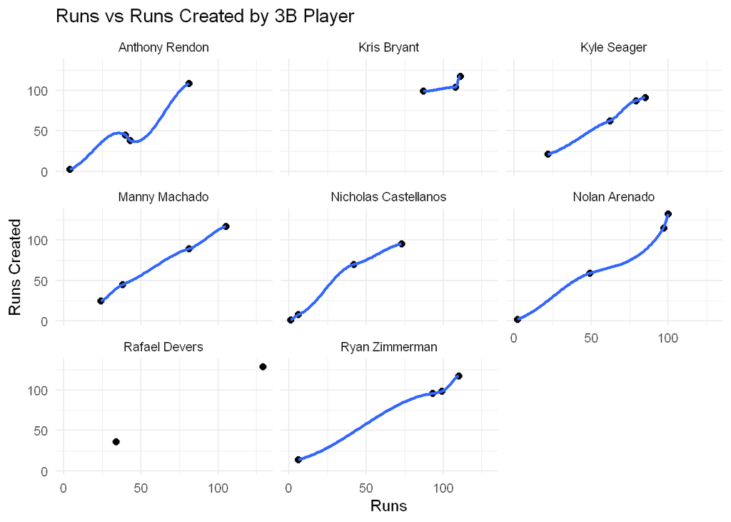

In reviewing the Runs Created metric, I would say Ryan Zimmerman and Nolan Arenado add most value.

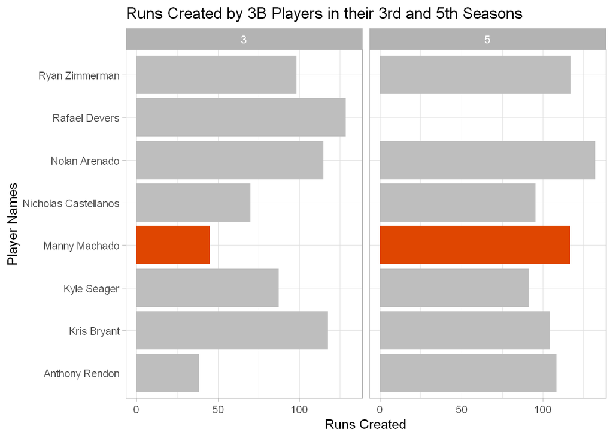

Now let’s compare WAR for these players. WAR is used to decide how many more wins one player is worth over another who plays in the same position. More specifically, Wins Above Replacement (WAR) is a baseball statistic used to measure a player’s total contribution to the team. When a team is contemplating trading one player for another, WAR is a measure reviewed to see what increased value the trade may provide to the team.

In reviewing WAR Ratings on stathead.com from the 1st, 3rd, 5th and 8th seasons, I found Manny Machado helped the Orioles win more games than could have been expected by a replacement level player.

Season 1: Manny’s WAR was 1.6, average WAR for all players was 1.5

Season 3: Manny’s WAR was 2.2, average WAR for all players was 3.7

Season 5: Manny’s WAR was 7.3, average wAR for all players was 5.3

Season 8: Manny’s WAR was 2.6, average WAR for all players was 1.3

#### WAR Performance Guide:

Scrub: 0-1 WAR, Role Player: 1-2 WAR, Solid Starter: 2-3 WAR, Good Player: 3-4 WAR, All-Star: 4-5 WAR, Superstar: 5-6 WAR, MVP: 6+ WAR

```r
mean(playerstable$WAR)
```

```
## [1] 2.965517
```

```r
aggregate(x = playerstable$WAR, by = list(playerstable$Season), FUN = mean)
```

```
##   Group.1     x
## 1       1 1.500
## 2       3 3.675
## 3       5 5.300
## 4       8 1.250
```

```r
mean(playerstable$WAR)
```

```
## [1] 2.965517
```

```r
aggregate(x = playerstable$WAR, by = list(playerstable$Name), FUN = mean)
```

```
##                Group.1        x
## 1       Anthony Rendon 1.775000
## 2          Kris Bryant 4.866667
## 3          Kyle Seager 2.625000
## 4        Manny Machado 3.425000
## 5 Nicholas Castellanos 0.575000
## 6        Nolan Arenado 3.875000
## 7        Rafael Devers 2.900000
## 8       Ryan Zimmerman 4.125000
```

Looking at the average WAR by Player, Kris Bryant, Ryan Zimmerman and Nolan Arenado have the top 3 scores. Manny is 4th of 8 players reviewed.

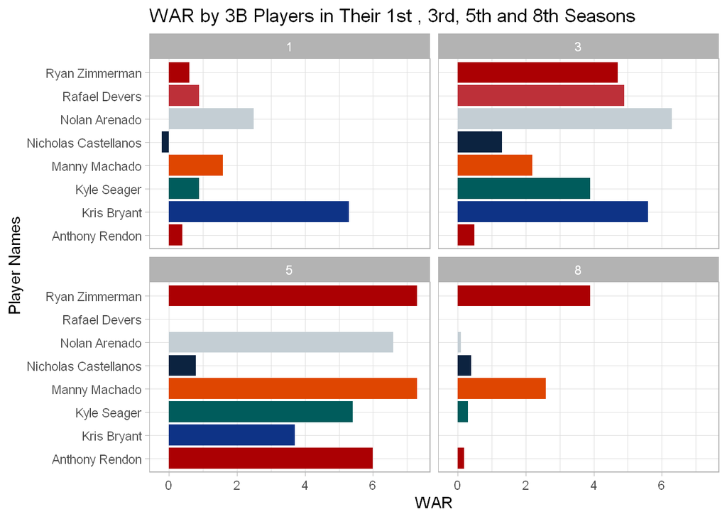

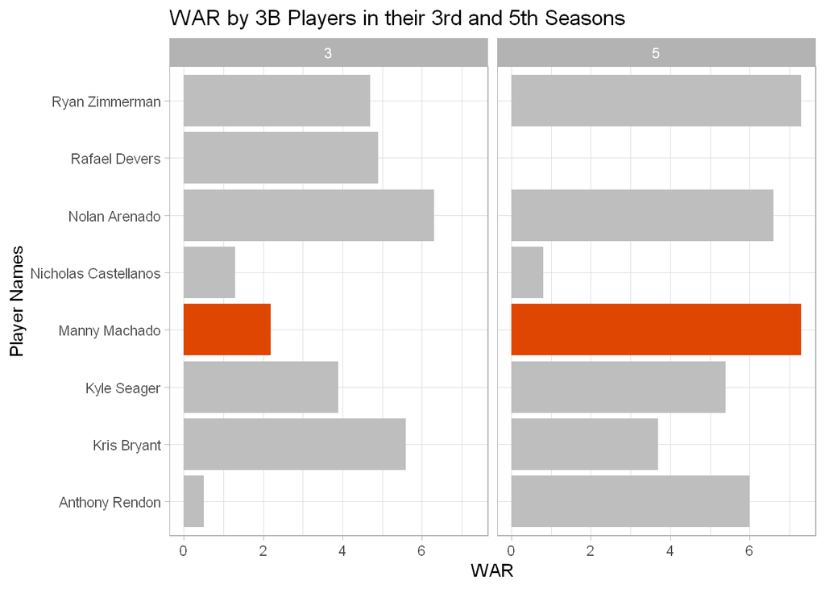

With 2018 being their worst season in 10 years I am looking forward to seeing them rebuild their team and turn it around for the Orioles.

NOTES: Manny Machado - Baltimore Orioles - Hex color Orange = #DF4601 Rafael Devers - Boston Red Sox - Red = #BD3039 Kris Bryant - Chicago Cubs - Blue = #0E3386 Nolan Arenado - Colorado Rockies - Grey = #C4CED4 Nicholas Castellanos - Detroit Tigers - Navy = #0C2340 Kyle Seager - Seattle Mariners - Green = #005C5C Ryan Zimmerman - Washington Nationals - Red = #AB0003 Anthony Rendon - Washington Nationals - Red = #AB0003